# Project Foundations for Data Science: FoodHub Data Analysis

**Marks: 60**

### Context

The number of restaurants in New York is increasing day by day. Lots of students and busy professionals rely on those restaurants due to their hectic lifestyles. Online food delivery service is a great option for them. It provides them with good food from their favorite restaurants. A food aggregator company FoodHub offers access to multiple restaurants through a single smartphone app.

The app allows the restaurants to receive a direct online order from a customer. The app assigns a delivery person from the company to pick up the order after it is confirmed by the restaurant. The delivery person then uses the map to reach the restaurant and waits for the food package. Once the food package is handed over to the delivery person, he/she confirms the pick-up in the app and travels to the customer's location to deliver the food. The delivery person confirms the drop-off in the app after delivering the food package to the customer. The customer can rate the order in the app. The food aggregator earns money by collecting a fixed margin of the delivery order from the restaurants.

### Objective

The food aggregator company has stored the data of the different orders made by the registered customers in their online portal. They want to analyze the data to get a fair idea about the demand of different restaurants which will help them in enhancing their customer experience. Suppose you are hired as a Data Scientist in this company and the Data Science team has shared some of the key questions that need to be answered. Perform the data analysis to find answers to these questions that will help the company to improve the business.

### Data Description

The data contains the different data related to a food order. The detailed data dictionary is given below.

### Data Dictionary

- order_id: Unique ID of the order
- customer_id: ID of the customer who ordered the food
- restaurant_name: Name of the restaurant
- cuisine_type: Cuisine ordered by the customer
- cost: Cost of the order
- day_of_the_week: Indicates whether the order is placed on a weekday or weekend (The weekday is from Monday to Friday and the weekend is Saturday and Sunday)
- rating: Rating given by the customer out of 5
- food_preparation_time: Time (in minutes) taken by the restaurant to prepare the food. This is calculated by taking the difference between the timestamps of the restaurant's order confirmation and the delivery person's pick-up confirmation.
- delivery_time: Time (in minutes) taken by the delivery person to deliver the food package. This is calculated by taking the difference between the timestamps of the delivery person's pick-up confirmation and drop-off information

### Let us start by importing the required libraries

```python
# import libraries for data manipulation
import numpy as np
import pandas as pd

# import libraries for data visualization
import matplotlib.pyplot as plt
import seaborn as sns

# Command to tell Python to actually display the graphs
%matplotlib inline

# to restrict the float value to 3 decimal places
pd.set_option('display.float_format', lambda x: '%.3f' % x)

# Library to suppress warnings
import warnings
warnings.filterwarnings('ignore')
```

```python
#Mount google drive to run notebook in google collab
from google.colab import drive
drive.mount('/content/drive')
```

### Understanding the structure of the data

```python
# read the data
df = pd.read_csv('/content/drive/MyDrive/Python_Course/Project1/foodhub_order.csv')
# returns the first 5 rows
df.head()
```

|  | order_id | customer_id | restaurant_name | cuisine_type | cost_of_the_order | day_of_the_week | rating | food_preparation_time | delivery_time |
| --- | --- | --- | --- | --- | --- | --- | --- | --- | --- |
| 0 | 1477147 | 337525 | Hangawi | Korean | 30.750 | Weekend | Not given | 25 | 20 |
| 1 | 1477685 | 358141 | Blue Ribbon Sushi Izakaya | Japanese | 12.080 | Weekend | Not given | 25 | 23 |
| 2 | 1477070 | 66393 | Cafe Habana | Mexican | 12.230 | Weekday | 5 | 23 | 28 |
| 3 | 1477334 | 106968 | Blue Ribbon Fried Chicken | American | 29.200 | Weekend | 3 | 25 | 15 |
| 4 | 1478249 | 76942 | Dirty Bird to Go | American | 11.590 | Weekday | 4 | 25 | 24 |

#### Observations:

The DataFrame has 9 columns as mentioned in the Data Dictionary. Data in each row corresponds to the order placed by a customer.

### **Question 1:** How many rows and columns are present in the data? [0.5 mark]

```python
df.shape
print("Data has",df.shape[0],"rows and",df.shape[1],"columns.")
```

```
Data has 1898 rows and 9 columns.
```

#### Observations:

The data frame has 1898 rows and 9 columns

### **Question 2:** What are the datatypes of the different columns in the dataset? (The info() function can be used) [0.5 mark]

```python
df.info()# Use info() to print a concise summary of the DataFrame
```

```
<class 'pandas.core.frame.DataFrame'>
RangeIndex: 1898 entries, 0 to 1897
Data columns (total 9 columns):
 #   Column                 Non-Null Count  Dtype
---  ------                 --------------  -----
 0   order_id               1898 non-null   int64
 1   customer_id            1898 non-null   int64
 2   restaurant_name        1898 non-null   object
 3   cuisine_type           1898 non-null   object
 4   cost_of_the_order      1898 non-null   float64
 5   day_of_the_week        1898 non-null   object
 6   rating                 1898 non-null   object
 7   food_preparation_time  1898 non-null   int64
 8   delivery_time          1898 non-null   int64
dtypes: float64(1), int64(4), object(4)
memory usage: 133.6+ KB
```

#### Observations:

1. All columns do not have any null values
2. Columns order_id, customer_id, food_preparation_time, delivery_time are of type int and this is expected of these kinds of entries
3. Columns rating, day_of_the_week, cuisine_type, restaurant_name are of type object. Rating can be processed to manage missing values in order to analyze available data as of type int.
4. Columns day_of_the_week, cuisine_type, and restaurant_name can remain as objects or be converted to type string
5. Column cost_of_the_order is of type float

### **Question 3:** Are there any missing values in the data? If yes, treat them using an appropriate method. [1 mark]

```python
# Create a tally of column names and count of missing values
df.isnull().sum()
```

|  | 0 |
| --- | --- |
| order_id | 0 |
| customer_id | 0 |
| restaurant_name | 0 |
| cuisine_type | 0 |
| cost_of_the_order | 0 |
| day_of_the_week | 0 |
| rating | 0 |
| food_preparation_time | 0 |
| delivery_time | 0 |

**dtype:** int64

#### Observations:

1. The data table does not have any missing values for all columns

### **Question 4:** Check the statistical summary of the data. What is the minimum, average, and maximum time it takes for food to be prepared once an order is placed? [2 marks]

```python
# Generate a statistical summary of the data set
df.describe().T
```

|  | count | mean | std | min | 25% | 50% | 75% | max |
| --- | --- | --- | --- | --- | --- | --- | --- | --- |
| order_id | 1898.000 | 1477495.500 | 548.050 | 1476547.000 | 1477021.250 | 1477495.500 | 1477969.750 | 1478444.000 |
| customer_id | 1898.000 | 171168.478 | 113698.140 | 1311.000 | 77787.750 | 128600.000 | 270525.000 | 405334.000 |
| cost_of_the_order | 1898.000 | 16.499 | 7.484 | 4.470 | 12.080 | 14.140 | 22.297 | 35.410 |
| food_preparation_time | 1898.000 | 27.372 | 4.632 | 20.000 | 23.000 | 27.000 | 31.000 | 35.000 |
| delivery_time | 1898.000 | 24.162 | 4.973 | 15.000 | 20.000 | 25.000 | 28.000 | 33.000 |

#### Observations:

1. The minimum time required for food preparation is 20 minutes
2. The average time required for food preparation is 27.372 minutes
3. The maximum time required for food preparation is 35 minutes

#### Additional Observations:

1. Statistics on order_id and customer_id are not meaningful e.g. mean
2. The mean of food preparation and delivery time is closely matched to the respective median of these metrics suggesting a well centered population with no extreme outliers

```python
df.describe(exclude = 'number').T
```

|  | count | unique | top | freq |
| --- | --- | --- | --- | --- |
| restaurant_name | 1898 | 178 | Shake Shack | 219 |
| cuisine_type | 1898 | 14 | American | 584 |
| day_of_the_week | 1898 | 2 | Weekend | 1351 |
| rating | 1898 | 4 | Not given | 736 |

#### Observations

1. There are 178 restuarants that supply orders and most orders are placed for Shake Shack
2. There are 14 types of cuisines in the data set with most orders being placed for American cuisine
3. The day of the week with most orders is weekends
4. Most orders do not have a rating assigned

### **Question 5:** How many orders are not rated? [1 mark]

```python
#Count and print the number of unique rating value
category = ['rating']
for category_Value in category:
  print(df[category_Value].value_counts())
```

```
rating
Not given    736
5            588
4            386
3            188
Name: count, dtype: int64
```

#### Observations:

1. There are 736 data rows where the rating is not given

```python
#Count and print the percent of unique rating value
category = ['rating']
for category_Value in category:
  print(df[category_Value].value_counts(normalize=True))
```

```
rating
Not given   0.388
5           0.310
4           0.203
3           0.099
Name: proportion, dtype: float64
```

### Exploratory Data Analysis (EDA)

### **Question 6:** Explore all the variables and provide observations on their distributions. (Generally, histograms, boxplots, countplots, etc. are used for univariate exploration.) [9 marks]

```python
#Define method to plot countplot along with percent values for non-continuous data columns
def count_plot_withPercent(data, columnForAnalysis):
  plt.figure(figsize=(15,5))

  data[columnForAnalysis] = data[columnForAnalysis].astype('category')

  ax = sns.countplot(data=data, x = columnForAnalysis, order=data[columnForAnalysis].value_counts().index)

  for bar in ax.patches:
    percentage = '{:.1f}%'.format(bar.get_height()/len(data[columnForAnalysis]) * 100)
    x = bar.get_x() + bar.get_width()/2 - 0.25
    y = bar.get_y() + bar.get_height()
    ax.annotate(percentage, (x,y), size=12)

  plt.xticks(rotation = 90)
  plt.show()

  #Print counts of reach unique value
  category = [columnForAnalysis]
  for col in category:
    print(df[col].value_counts())

  print("There are",data[columnForAnalysis].nunique(),"unique categories in column",columnForAnalysis)
```

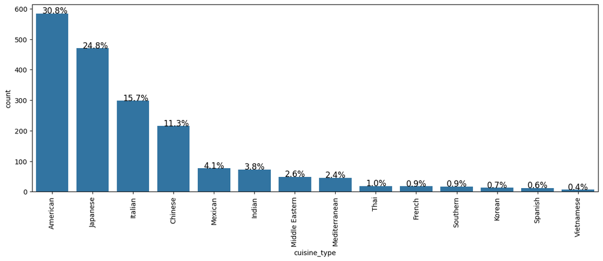

```
cuisine_type
American          584
Japanese          470
Italian           298
Chinese           215
Mexican            77
Indian             73
Middle Eastern     49
Mediterranean      46
Thai               19
French             18
Southern           17
Korean             13
Spanish            12
Vietnamese          7
Name: count, dtype: int64
There are 14 unique categories in column cuisine_type
```

```python
#plot a count plot of Restuarant Name
count_plot_withPercent(df,'cuisine_type')
```

#### Observations:

1. American is the most popular cuisine followed by Japanese and Italian in that order
2. Vietnamese cuisine has the least number of orders

[figure not shown]

```
restaurant_name
Shake Shack                  219
The Meatball Shop            132
Blue Ribbon Sushi            119
Blue Ribbon Fried Chicken     96
Parm                          68
                            ...
Klong                          1
Kambi Ramen House              1
Il Bambino                     1
Hunan Manor                    1
Lamarca Pasta                  1
Name: count, Length: 178, dtype: int64
There are 178 unique categories in column restaurant_name
```

```python
#plot a count plot of Restuarant Name
count_plot_withPercent(df,'restaurant_name')
```

#### Observations

1. Shake shack has the most number of orders
2. There are 178 unique restuarants in the data set which makes it challenging to visualize all the data. Looking at for example top 50 restaurants in terms of order counts may create a easier to view graph but we would preserve all the data for decisions

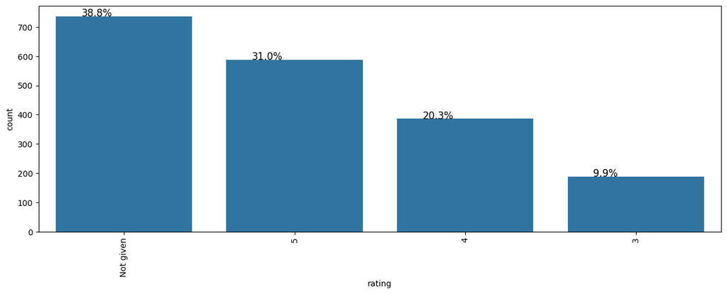

```
rating
Not given    736
5            588
4            386
3            188
Name: count, dtype: int64
There are 4 unique categories in column rating
```

```python
count_plot_withPercent(df,'rating')
```

#### Observations

1. Most orders do not have a rating
2. 31% of the orders receive a rating of 5
3. Customers are more enthusiastic to report a good experience and give a good review since a rating of 5 is the most prevalent. A rating of 4 is also high.

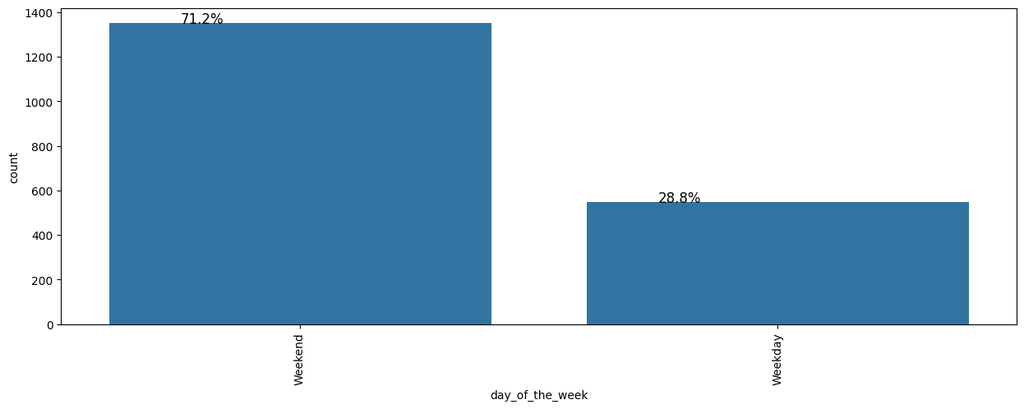

```
day_of_the_week
Weekend    1351
Weekday     547
Name: count, dtype: int64
There are 2 unique categories in column day_of_the_week
```

```python
count_plot_withPercent(df,'day_of_the_week')
```

#### Observations

1. Most orders are placed on the weekends (71.2%)
2. Only 28.8% of orders are placed during a week day

```python
df['customer_id'].value_counts()
```

| customer_id | count |
| --- | --- |
| 52832 | 13 |
| 47440 | 10 |
| 83287 | 9 |
| 250494 | 8 |
| 259341 | 7 |
| ... | ... |
| 385426 | 1 |
| 254913 | 1 |
| 289597 | 1 |
| 74412 | 1 |
| 397537 | 1 |

1200 rows × 1 columns

**dtype:** int64

#### Observations

1. There are 1200 customers served as identified by a unique customerID
2. The count plot of all these unique customers is not easy to read and would need aggregation
3. Customer with ID 52832 has placed the highest number of orders (13)

```python
df['order_id'].value_counts()
```

| order_id | count |
| --- | --- |
| 1477147 | 1 |
| 1477697 | 1 |
| 1477555 | 1 |
| 1478028 | 1 |
| 1478308 | 1 |
| ... | ... |
| 1478087 | 1 |
| 1476775 | 1 |
| 1478421 | 1 |
| 1476774 | 1 |
| 1478056 | 1 |

1898 rows × 1 columns

**dtype:** int64

#### Observations

```python
#Define a method to plot a histogram for a given column showing the mean
def plot_histogramNBoxPlot(data, columnName, figsize=(15,10)):
  ax = sns.histplot(data=data,x=columnName,kde=True)
  mean_value = np.mean(df[columnName])
  median_value = np.median(df[columnName])
  ax.axvline(mean_value,color='g',linestyle='--',label='Mean')
  ax.axvline(median_value,color='b',linestyle='-', label='Median')

  plt.show()

  ay = sns.boxplot(data=data,x=columnName, showmeans=True)
  # Calculate statistics and annotate
  stats = data[columnName].describe()
  plt.show()
  print(stats)
```

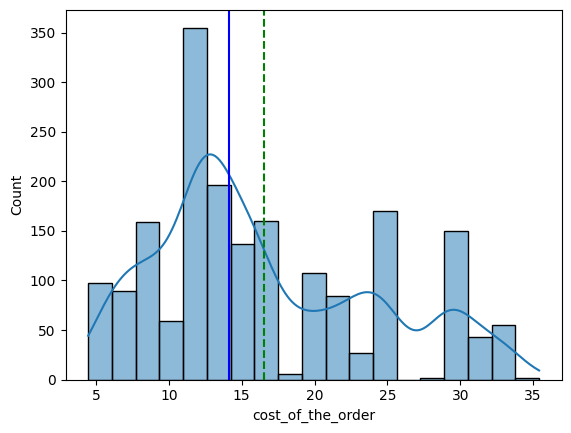

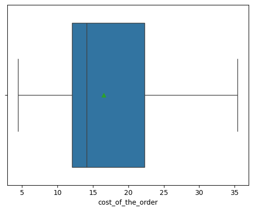

```
count   1898.000
mean      16.499
std        7.484
min        4.470
25%       12.080
50%       14.140
75%       22.297
max       35.410
Name: cost_of_the_order, dtype: float64
```

```python
plot_histogramNBoxPlot(df,'cost_of_the_order')
```

#### Observations

1. The median of the cost of an order is 14.1 which is less than the mean of 16.49 due to several high cost orders skewing the mean a bit higher
2. The box plot of cost of an order does not show any outliers
3. The distribution of cost of order is right skewed. This is shown in the box plot by the further tail position on the right.

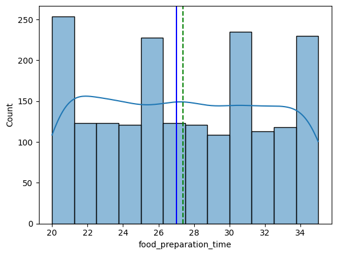

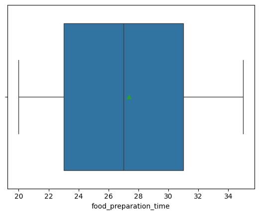

```
count   1898.000
mean      27.372
std        4.632
min       20.000
25%       23.000
50%       27.000
75%       31.000
max       35.000
Name: food_preparation_time, dtype: float64
```

```python
plot_histogramNBoxPlot(df,'food_preparation_time')
```

#### Observations

1. The food preparation time distribution is well centered. The mean (27.3) is very close to the median (27)
2. The distribution of food time preparation shows no outliers
3. The quickest meal to prepare takes 20 minutes and the longest meal to prepare takes 35 minutes

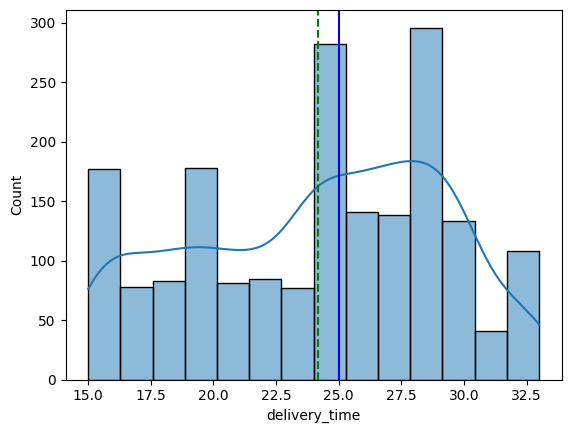

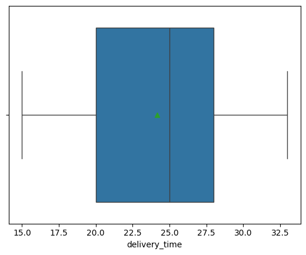

```
count   1898.000
mean      24.162
std        4.973
min       15.000
25%       20.000
50%       25.000
75%       28.000
max       33.000
Name: delivery_time, dtype: float64
```

```python
plot_histogramNBoxPlot(df,'delivery_time')
```

#### Observation

1. Food delivery time shows a well centered distribution. The mean is 24.16 while the median is 25. The mean and median values are close.
2. The mean is slightly less than the median suggesting that orders that are delivered quickly are skewing the mean slightly to the left.
3. The shortest delivery takes 15 minutes while the longest takes 33 minutes.

### **Question 7**: Which are the top 5 restaurants in terms of the number of orders received? [1 mark]

```python
category = ['restaurant_name']
for cat in category:
  print(df[cat].value_counts().head())
```

```
restaurant_name
Shake Shack                  219
The Meatball Shop            132
Blue Ribbon Sushi            119
Blue Ribbon Fried Chicken     96
Parm                          68
Name: count, dtype: int64
```

#### Observations:

*The top 5 restaurants are listed below in descending order of number of orders. Shake Shack receives the most orders:

1. Shake Shack - 219 orders
2. The Meatball Shop - 132 orders
3. Blue Ribbon Sushi - 119 orders
4. Blue Ribbon Fried Chicken - 96 orders
5. Parm - 68 orders

### **Question 8**: Which is the most popular cuisine on weekends? [1 mark]

```
Weekend Data
cuisine_type
American          415
Japanese          335
Italian           207
Chinese           163
Mexican            53
Indian             49
Mediterranean      32
Middle Eastern     32
Thai               15
French             13
Korean             11
Southern           11
Spanish            11
Vietnamese          4
Name: count, dtype: int64
```

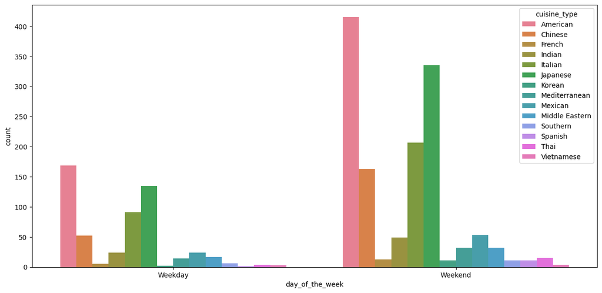

```python
columnName = ['cuisine_type']
for col in columnName:
  print('Weekend Data')
  print(df[df['day_of_the_week']=='Weekend'][col].value_counts())
plt.figure(figsize=(15,7))
sns.countplot(data=df,x='day_of_the_week',hue='cuisine_type')
plt.show()
```

#### Observations:

1. The most popular cuisine on the weekends in American

### **Question 9**: What percentage of the orders cost more than 20 dollars? [2 marks]

```python
#Find percent of orders that cost more that 20 dollars
cost_of_orders_withValueGT20 = len(df[df['cost_of_the_order']>20])/len(df['cost_of_the_order']) * 100
print(cost_of_orders_withValueGT20 )
```

```
29.24130663856691
```

### **Question 10**: What is the mean order delivery time? [1 mark]

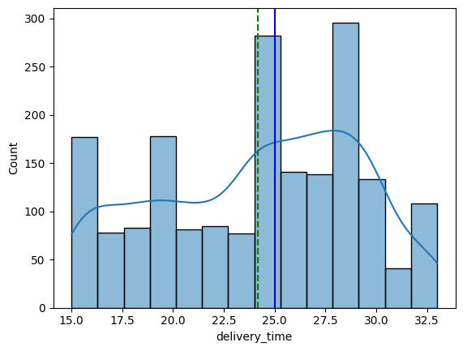

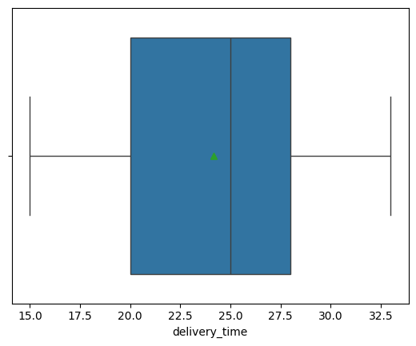

```
count   1898.000
mean      24.162
std        4.973
min       15.000
25%       20.000
50%       25.000
75%       28.000
max       33.000
Name: delivery_time, dtype: float64
```

```python
plot_histogramNBoxPlot(df,'delivery_time')
```

#### Observations:

1. The mean delivery time is 24.16 minutes

#### Other comments also mentioned above

1. Food delivery time shows a well centered distribution. The mean is 24.16 while the median is 25. The mean and median values are close.
2. The mean is slightly less than the median suggesting that orders that are delivered quickly are skewing the mean slightly to the left.
3. The shortest delivery takes 15 minutes while the longest takes 33 minutes

### **Question 11:** The company has decided to give 20% discount vouchers to the top 3 most frequent customers. Find the IDs of these customers and the number of orders they placed. [1 mark]

```python
res = df['customer_id'].value_counts()
res
```

| customer_id | count |
| --- | --- |
| 52832 | 13 |
| 47440 | 10 |
| 83287 | 9 |
| 250494 | 8 |
| 259341 | 7 |
| ... | ... |
| 385426 | 1 |
| 254913 | 1 |
| 289597 | 1 |
| 74412 | 1 |
| 397537 | 1 |

1200 rows × 1 columns

**dtype:** int64

```python
def DetermineFirstN(data, category, N):
  categoryArray = [category]
  count = 0

  for columnCategory in categoryArray:
      resultValueCounts = data[columnCategory].value_counts()
      while(count < N):
        print(count, "customer with ID",resultValueCounts.index[count],"has made", resultValueCounts.values[count], "orders.")
        count +=1

DetermineFirstN(df,'customer_id',3)
```

```
0 customer with ID 52832 has made 13 orders.
1 customer with ID 47440 has made 10 orders.
2 customer with ID 83287 has made 9 orders.
```

#### Observations:

1. The top 3 customers that qualify for 20% discount are:
- customer with ID 52832 has made 13 orders.
- customer with ID 47440 has made 10 orders.
- customer with ID 83287 has made 9 orders.

### **Question 12**: Perform a multivariate analysis to explore relationships between the important variables in the dataset. (It is a good idea to explore relations between numerical variables as well as relations between numerical and categorical variables) [10 marks]

```python
#Create method to create a heatmap of correlations between numeric data types
def createHeatMap(data):
  numeric_columns = data.select_dtypes(include=['number'])
  sns.heatmap(numeric_columns.corr(),annot=True,cmap='coolwarm')
```

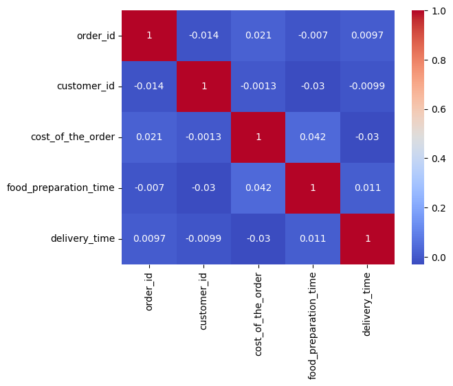

```python
#create heatmap of numeric data types in df dataset
createHeatMap(df)
```

#### Observations

```python
#Method to create a box plot between two variables
def createBoxPlot(data,x,y):
  plt.figure(figsize=(12,7))
  order = data.groupby(x)[y].median().sort_values(ascending=False).index
  sns.boxplot(data,x=x,y=y, order=order, palette='Set1',showmeans=True)
  plt.xticks(rotation = 90)
```

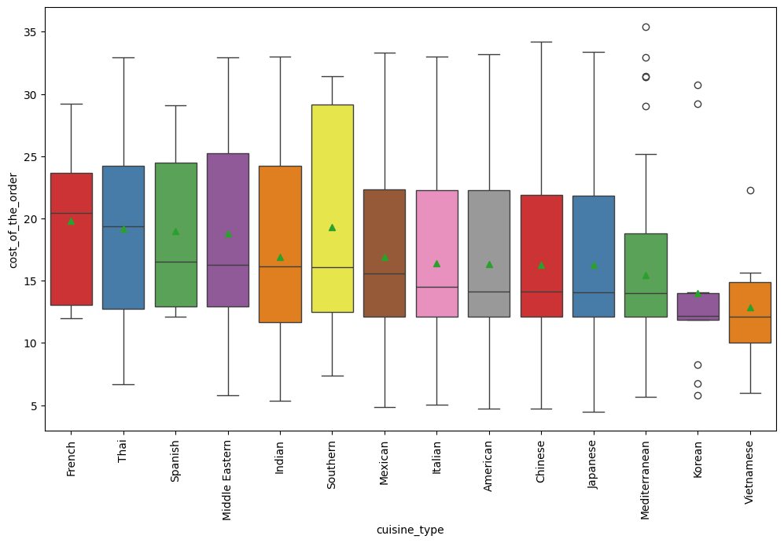

```python
createBoxPlot(df,'cuisine_type','cost_of_the_order')
```

#### Observations

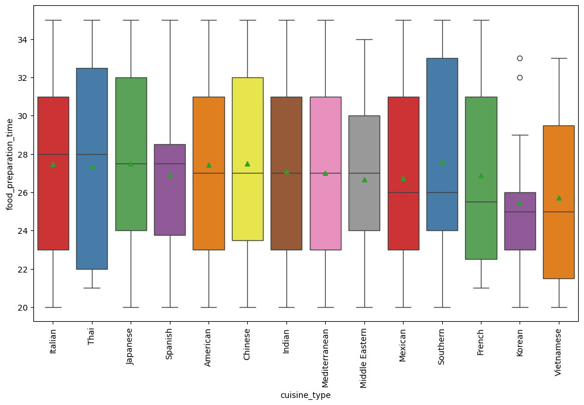

```python
#Examine relationship between cuisine and food preparation time
createBoxPlot(df,'cuisine_type','food_preparation_time')
```

#### Observations

1. 50 percent of italian orders take 28 minutes or more to prepare
2. In general, the median of all the cuisine preparation time falls between about 25 - 28 minutes.
3. 50 percent of Vietnamese cuisine orders take the shortest time to prepare of about 25 minutes
4. There are outliers in the preparation time for Korean food, where some orders take a long time to prepare

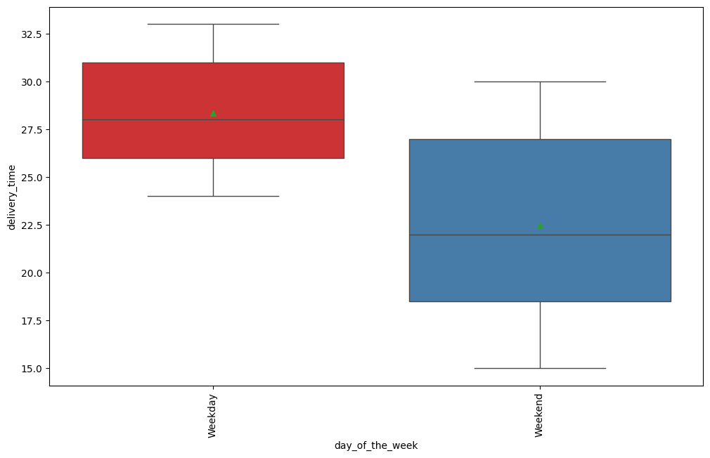

```python
# Examine relationship between the day of the week and delivery time
createBoxPlot(df,'day_of_the_week','delivery_time')
```

#### Observations:

1. Orders take longer to deliver during the weekday (median is about 28 minutes) that during the weekend (median is about 22 minutes). It is possible that there is less traffic during the weekend or perhaps more delivery drivers during the weekend.

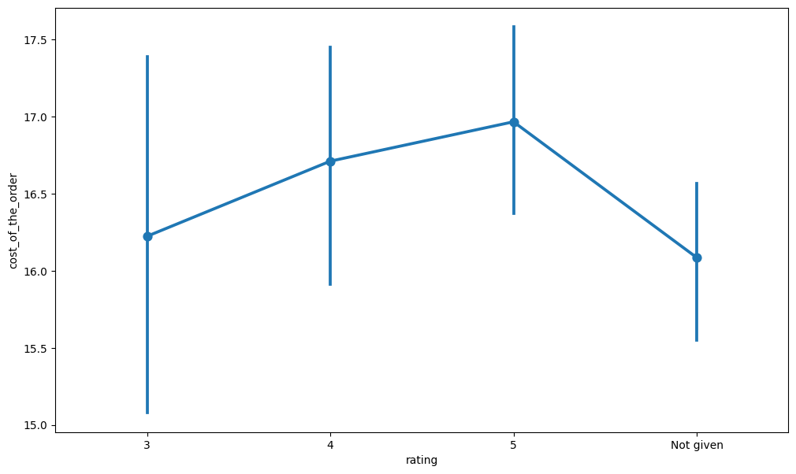

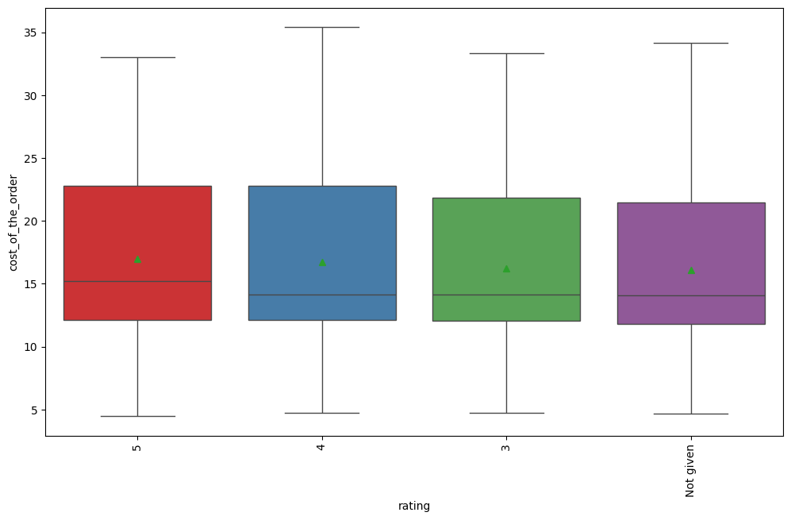

```python
#Explore the ralationship between the rating and the cost of the order
def createPointPlot(data,x,y):
  plt.figure(figsize=(12,7))
  sns.pointplot(data,x=x,y=y)
createPointPlot(df,'rating','cost_of_the_order')
createBoxPlot(df,'rating','cost_of_the_order')
```

#### Observations

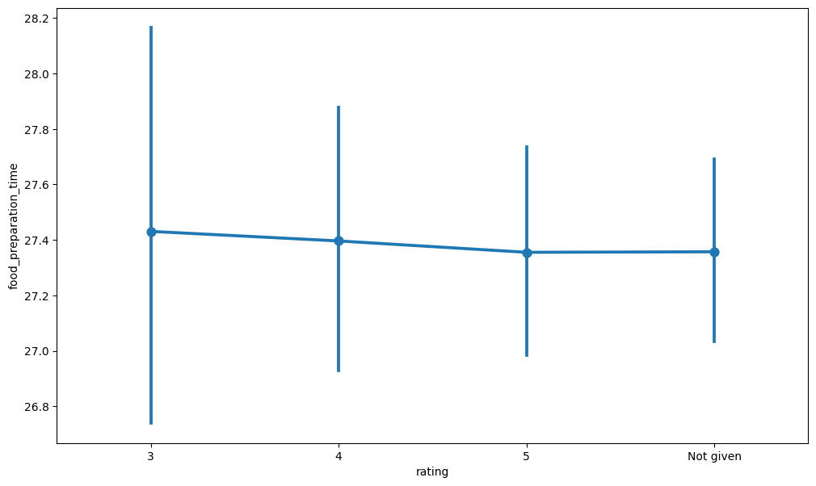

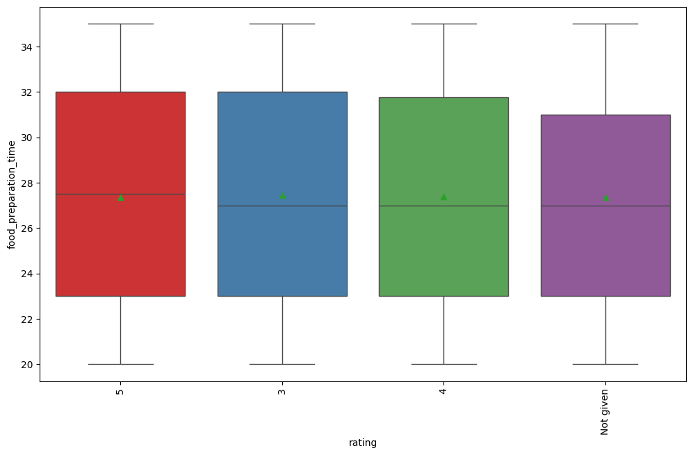

```python
#Explore relationship between rating and food preparation time
createPointPlot(df,'rating','food_preparation_time')
createBoxPlot(df,'rating','food_preparation_time')
```

#### Observations

1. The food preparation time does not change much for the various ratings assigned by customers
2. Food preparation time does not seem correlated with rating

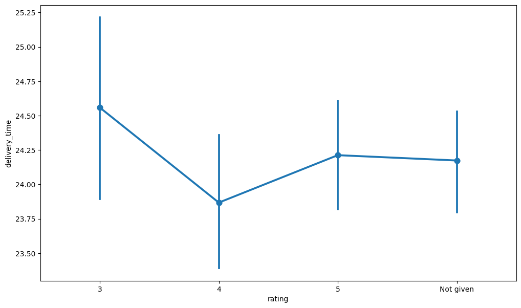

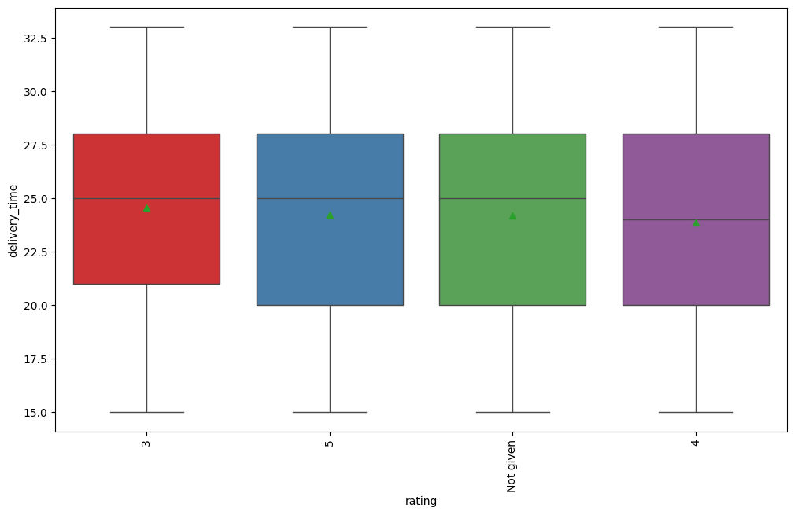

```python
#Explore the relationship between rating and delivery time
createPointPlot(df,'rating','delivery_time')
createBoxPlot(df,'rating','delivery_time')
```

#### Observations

```python
#Get insights on revenue for the various resturants
df.groupby('restaurant_name')['cost_of_the_order'].sum().sort_values(ascending=False).head(20)
```

| restaurant_name | cost_of_the_order |
| --- | --- |
| Shake Shack | 3579.530 |
| The Meatball Shop | 2145.210 |
| Blue Ribbon Sushi | 1903.950 |
| Blue Ribbon Fried Chicken | 1662.290 |
| Parm | 1112.760 |
| RedFarm Broadway | 965.130 |
| RedFarm Hudson | 921.210 |
| TAO | 834.500 |
| Han Dynasty | 755.290 |
| Blue Ribbon Sushi Bar & Grill | 666.620 |
| Rubirosa | 660.450 |
| Sushi of Gari 46 | 640.870 |
| Nobu Next Door | 623.670 |
| Five Guys Burgers and Fries | 506.470 |
| Momoya | 492.130 |
| Chipotle Mexican Grill $1.99 Delivery | 491.690 |
| Blue Ribbon Sushi Izakaya | 485.090 |
| Tamarind TriBeCa | 426.710 |
| Jack's Wife Freda | 416.750 |
| Bareburger | 399.740 |

**dtype:** float64

#### Observations

1. The restaurants with the highest revenue are: Shake Shack, The Meatball Shop, and Blue Ribbon Sushi in that order.

```python
df['Revenue'] = df.groupby('restaurant_name')['cost_of_the_order'].transform('sum')
df['OrderCount'] = df.groupby('restaurant_name')['order_id'].transform('count')
```

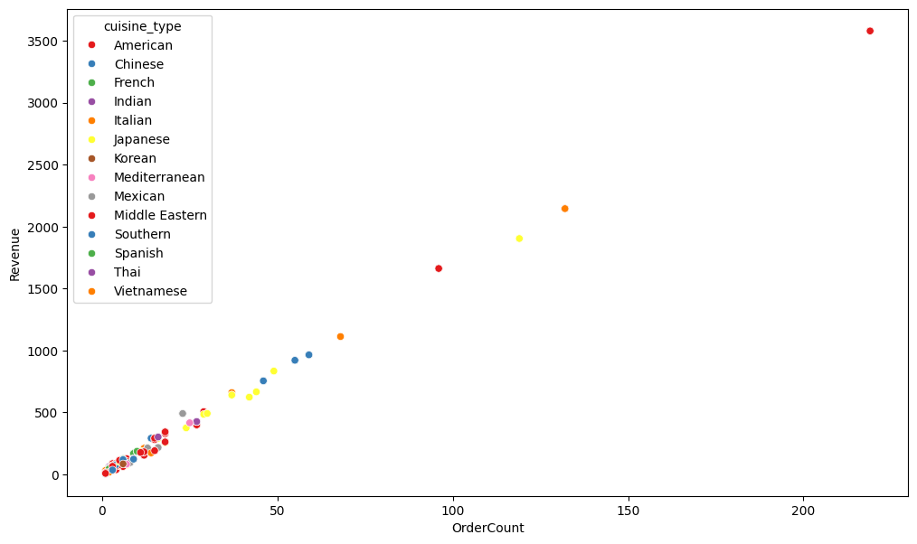

```python
#Understand how order counts relate to revenue
def createScatterPlot(data,x,y,z):
  plt.figure(figsize=(12,7))
  sns.scatterplot(data=data,x=x,y=y,hue=z,palette='Set1')

createScatterPlot(df,'OrderCount','Revenue','cuisine_type')
```

#### Observations

1. To increase revenue a restuarant should strive to get more orders
2. An American cuisine restuarant has the highest number of orders and the highest revenue. The difference of the restuarant with the highest revenue to other restuarants is significant.

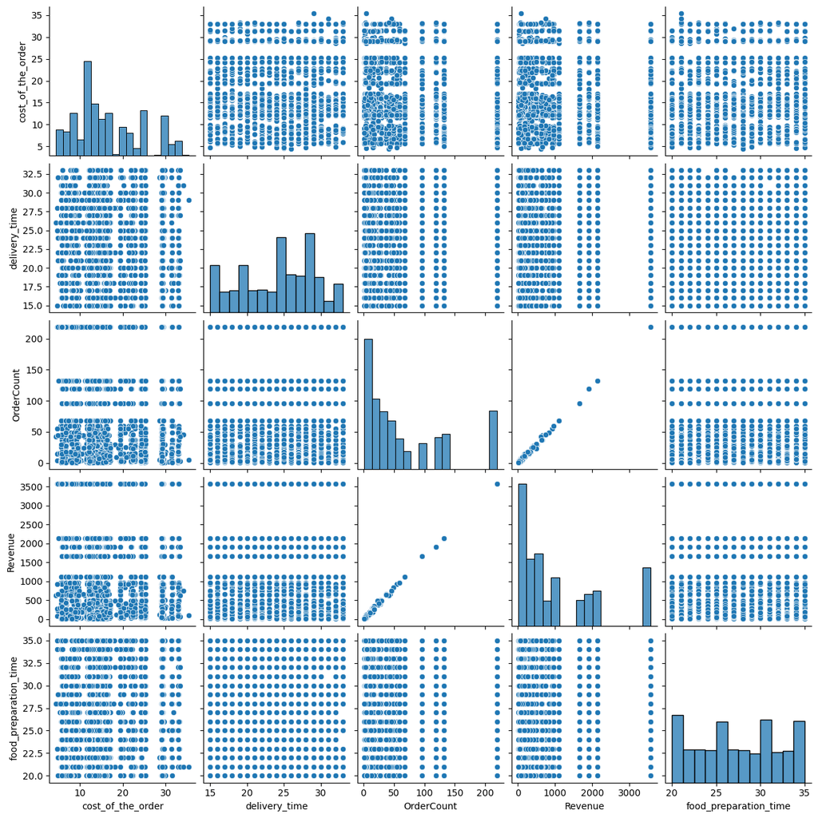

```python
def createPairPlot(data):
  plt.figure(figsize=(15,7))
  sns.pairplot(data=data)
  plt.show()

createPairPlot(df[['cost_of_the_order','delivery_time','OrderCount','Revenue','food_preparation_time']])
```

#### Observations

1. The strongest correlation is between order count and revenue. The higher the number of orders, the higher the revenue
2. From the histogram of revenue and order count, we see that a lot of restuarants make little money and have few orders
3. For many other variables, it is challenging to determine the correlations

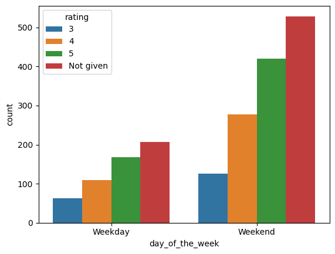

```python
sns.countplot(df,x='day_of_the_week',hue='rating')
```

#### Observations

1. There are more orders over the weekend
2. The ratings follow the same trend whether an order is placed during a weekday or weekend. Most orders do not receive a rating. The highest frequency ratiing is 5 followed by 4 and then 3.

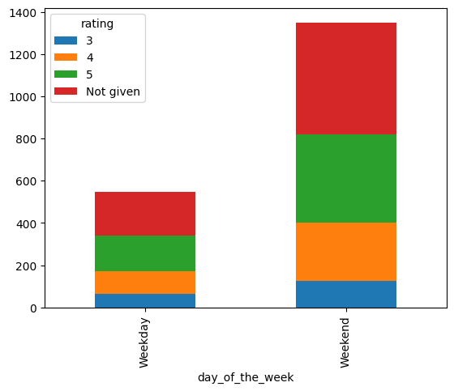

```python
df_crosstab = pd.crosstab(df['day_of_the_week'],df['rating'])
df_crosstab.plot(kind='bar', stacked=True)
```

#### Observations

1. There are more orders over the weekend
2. The ratings follow the same trend whether an order is placed during a weekday or weekend. Most orders do not receive a rating. The highest frequency ratiing is 5 followed by 4 and then 3.

### **Question 13:** The company wants to provide a promotional offer in the advertisement of the restaurants. The condition to get the offer is that the restaurants must have a rating count of more than 50 and the average rating should be greater than 4. Find the restaurants fulfilling the criteria to get the promotional offer. [3 marks]

```python
#Create a dataframe with restuarants where rating is assigned and convert it to numeric type
dfwithRatingAssigned = df[df['rating']!='Not given']
dfwithRatingAssigned['rating'] = dfwithRatingAssigned['rating'].astype(str)
dfwithRatingAssigned['rating_numeric'] = pd.to_numeric(dfwithRatingAssigned['rating'])

#Create new columns with the count of ratings and rating average
dfwithRatingAssigned['rating_count'] = dfwithRatingAssigned.groupby('restaurant_name')['rating_numeric'].transform('count')
dfwithRatingAssigned['rating_average'] = dfwithRatingAssigned.groupby('restaurant_name')['rating_numeric'].transform('mean')

#Find restaurants with rating count of > 50 and an average rating >4
dfQualifyForAdvertPromotion = dfwithRatingAssigned.loc[(dfwithRatingAssigned['rating_count']>50) & (dfwithRatingAssigned['rating_average']>4)]
dfQualifyForAdvertPromotion.shape

#Restaurants qualifying for the promotional advertisement are:
category = ['restaurant_name']
for cat in category:
  count = dfQualifyForAdvertPromotion[cat].value_counts(dropna=True)
  count = count[count>0]
  print(count)
```

```
restaurant_name
Shake Shack                  133
The Meatball Shop             84
Blue Ribbon Sushi             73
Blue Ribbon Fried Chicken     64
Name: count, dtype: int64
```

#### Observation

1. The restuarants qualifying for the promotion are: Shake Shack, The Meatball Shop, Blue Ribbon Sushi and Blue Ribbon Fried Chicken

### **Question 14:** The company charges the restaurant 25% on the orders having cost greater than 20 dollars and 15% on the orders having cost greater than 5 dollars. Find the net revenue generated by the company across all orders. [3 marks]

```python
def determineFoodDeliveryCharge(order_cost):
  if(order_cost > 20):
    return order_cost*0.25
  elif(5 < order_cost <= 20): #Noticed that the minimum food cost is 4.470 but decided to treat it like $5 since it is reasonable that the food delivery company should change a fee even for low cost orders
    return order_cost*0.15
  else:
    return 0

#Create a new column is dataframe with the delivery charge:
df['Delivery_Fee'] = df['cost_of_the_order'].apply(determineFoodDeliveryCharge)

print('The delivery service total revenue is',df['Delivery_Fee'].sum(),'dollars')
```

```
The delivery service total revenue is 6166.303 dollars
```

### **Question 15:** The company wants to analyze the total time required to deliver the food. What percentage of orders take more than 60 minutes to get delivered from the time the order is placed? (The food has to be prepared and then delivered.) [2 marks]

```python
#Compute the total food delivery time which is the sum of preparation and delivery time
df['Total_Food_Delivery_Time'] = df['food_preparation_time'] + df['delivery_time']

print(len(df[df['Total_Food_Delivery_Time']>60]))

percentOrdersWithGreaterThan60MinutesForDelivery = round(len(df[df['Total_Food_Delivery_Time']>60])/len(df['Total_Food_Delivery_Time']) * 100,2)
print('Percentage of orders that take more than 60 minutes to deliver is',percentOrdersWithGreaterThan60MinutesForDelivery,'%')
```

```
200
Percentage of orders that take more than 60 minutes to deliver is 10.54 %
```

#### Observations:

### **Question 16:** The company wants to analyze the delivery time of the orders on weekdays and weekends. How does the mean delivery time vary during weekdays and weekends? [2 marks]

```python
#Method to detemine mean delivery time for different categories in a dataframe column
def determineMeanForCategory(data, columnName, categoryColumn):
  category = [categoryColumn]
  for cat in category:
    meanForCategory = data.groupby(cat)[columnName].mean()
    print(meanForCategory)

determineMeanForCategory(df,'delivery_time','day_of_the_week')
determineMeanForCategory(df,'Total_Food_Delivery_Time','day_of_the_week')
```

```
day_of_the_week
Weekday   28.340
Weekend   22.470
Name: delivery_time, dtype: float64
day_of_the_week
Weekday   55.552
Weekend   49.907
Name: Total_Food_Delivery_Time, dtype: float64
```

#### Observations:

1. On average, the delivery times over the weekend is shorter (22.47 minutes) compared to during the weekday (28.34 minutes)
2. Similarly, the average total delivery time (preparation + delivery) is shorter during the weekend (49.9 minutes) compared to the weekdays (55.6 minutes)

### Conclusion and Recommendations

### **Question 17:** What are your conclusions from the analysis? What recommendations would you like to share to help improve the business? (You can use cuisine type and feedback ratings to drive your business recommendations.) [6 marks]

```python
#Create a cross tabulation of cuisine, rating, and sum of revenue
ct = pd.crosstab(df['cuisine_type'],df['rating'],values=df['Delivery_Fee'],aggfunc='sum')
print(ct)
```

```
rating               3       4       5  Not given
cuisine_type
American       210.628 401.879 624.885    640.881
Chinese         69.058 133.892 213.976    273.115
French           4.780  11.516  25.504     34.392
Indian          23.668  26.018 115.876     81.433
Italian         82.284 189.053 323.764    371.784
Japanese       138.483 294.524 436.984    608.254
Korean           3.348  12.851   4.468     12.636
Mediterranean   25.352  25.231  45.393     40.352
Mexican          9.858  75.531  65.648    105.656
Middle Eastern  24.296  72.673  49.980     46.605
Southern         5.577  22.718  22.021     18.438
Spanish          0.000   7.263  18.196     21.778
Thai             0.000   6.716  29.850     41.487
Vietnamese       3.252   1.820   6.759      3.922
```

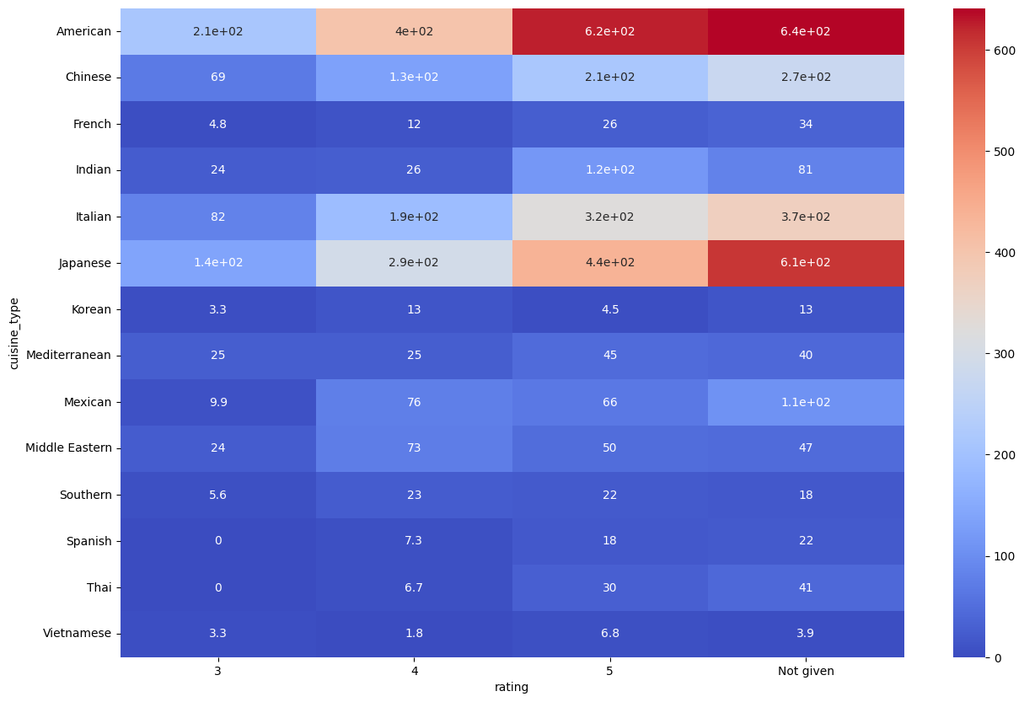

```python
#Create a heatmap of the above data
plt.figure(figsize=(15,10))
sns.heatmap(data = ct,cmap='coolwarm',annot=True)
plt.show()
```

```python
#Create a cross tabulation of cuisine, rating, and sum of revenue
ct = pd.crosstab(df['delivery_time'],df['rating'],values=df['Delivery_Fee'],aggfunc='sum')
print(ct)
```

```
rating             3       4       5  Not given
delivery_time
15            37.173  67.049 101.570    101.294
16            25.758  48.169 107.736    130.489
17             9.386  67.033 119.697     70.784
18             6.476  70.886  80.829     92.468
19            32.128  89.861  69.427    105.454
20            38.680  34.764 114.186    102.008
21            33.006 114.931  57.044    102.089
22            20.879  52.736  76.993    100.129
23            40.748  60.938  58.934     95.197
24            61.599 109.588 157.944    194.446
25            41.960  73.020 137.396    130.581
26            27.096  68.826 142.917    170.108
27            55.859  90.789 138.476    168.989
28            51.675  57.343 160.040    195.608
29            43.352 108.666 156.286    158.296
30            25.231  79.739 137.429    177.898
31            29.095  25.792  26.790     43.996
32            13.830  33.187  94.598     74.831
33             6.651  28.364  45.011     86.064
```

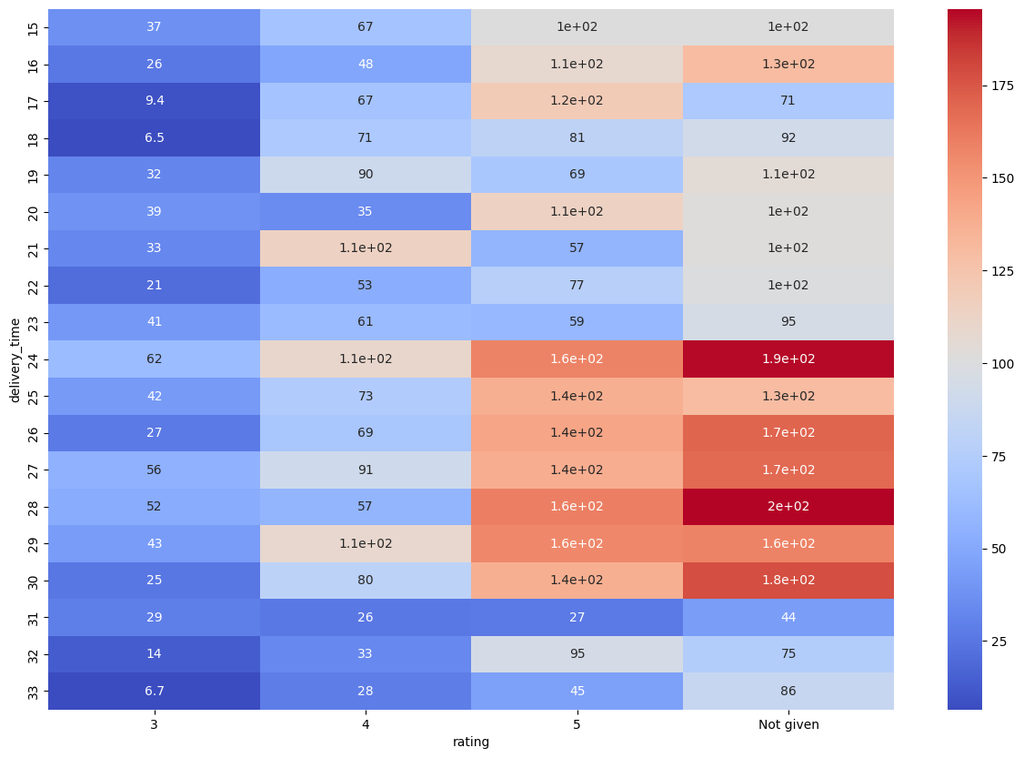

```python
#Create a heatmap of the above data
plt.figure(figsize=(15,10))
sns.heatmap(data = ct,cmap='coolwarm',annot=True)
plt.show()
```

### Recommendations:

1. Prioritize supporting more American and Japanese restaurants for profitability
2. Bring in high rating restaurants into the food hub support network to improve profitability. Restaurants with high ratings receive more orders.
3. Encourage restaurants to improve their ratings in order to increase customer orders and to generate higher income for the food hub company
4. Faster delivery times can improve ratings and higher ratings lead to more orders. The company should focus on reducing delivery times.

```python
! jupyter nbconvert --to html  '/content/drive/MyDrive/Python_Course/Project1/FDS_Project_LearnerNotebook_FullCode_MoureenKemei.ipynb'
```

```
[NbConvertApp] Converting notebook /content/drive/MyDrive/Python_Course/Project1/FDS_Project_LearnerNotebook_FullCode_MoureenKemei.ipynb to html
[NbConvertApp] Writing 1616803 bytes to /content/drive/MyDrive/Python_Course/Project1/FDS_Project_LearnerNotebook_FullCode_MoureenKemei.html
```